```r
library(tidyverse)
library(mdsr)
library(RMySQL)
db <- dbConnect_scidb(dbname = "imdb")
```

[figure not shown]

##### Author: Julia, Mylo, Nashshaba

### Problem Statement:

The *International Movie Database (IMDB)* is a well known internet database containing information pertaining to actors and movies. Society imposes binary gender options on individuals, so we explored how this manifests in the data stored with the *IMDB*.

### Analysis:

We used the names, person_info, and cast_info tables from the IMDB. These tables joined to provide the necessary information linking the actors and other data.

##### Gender IS Binary:

To begin our exploration of gender and its appearance in the *IMDB*, we utilized a function to count distinct options for the ‘Gender’ column of the ‘Names’ table. The return on this endeavor was 2, which indicates the IMDB is still enforcing the gender binary.

```r
db %>%
dbGetQuery("Select COUNT(DISTINCT gender)
           From name;")
```

```
##   COUNT(DISTINCT gender)
## 1                      2
```

##### Finding Transgender People in the *IMDB*:

The table below shows Joanna Fang, a random actor from the data set created in this process:

```r
trans_actors_whole_info <- db %>%
  dbGetQuery(" Select gender, name, note, person_id, info
FROM name
JOIN person_info on person_info.person_id= name.id
WHERE info LIKE '%trans%' AND
info is not NULL AND
info not LIKE '%transa%' AND
info not LIKE '%transb%' AND
info not LIKE '%transc%' AND
info not LIKE '%transd%' AND
info not LIKE '%transe%' AND
info not LIKE '%transh%' AND
info not LIKE '%transi%' AND
info not LIKE '%transj%' AND
info not LIKE '%transk%' AND
info not LIKE '%transl%' AND
info not LIKE '%transn%' AND
info not LIKE '%transo%' AND
info not LIKE '%transp%' AND
info not LIKE '%transq%' AND
info not LIKE '%transr%' AND
info not LIKE '%transt%' AND
info not LIKE '%transu%' AND
info not LIKE '%transv%' AND
info not LIKE '%transw%' AND
info not LIKE '%transx%' AND
info not LIKE '%transy%' AND
info not LIKE '%transz%' AND
info not LIKE '%transac%' AND
info not Like '%trans-racial%' AND
info not LIKE '%transp%' AND
info not LIKE '%transi%' AND
info not LIKE '%transc%' AND
info not Like '%trans media%' AND
info not like '%transfix%' AND
info not like '%trans-atlantic%' AND
info not LIKE '%transy%' AND
info not LIKE '%transfer%' AND
info not LIKE '%transfo%' AND
info not LIKE '%transat%' AND
info not LIKE '%transgre%' AND
info not LIKE '%transmu%' AND
info not LIKE '%transmit%' AND
info not LIKE '%transGr%' AND
info not LIKE '%transfigu%' AND
info not LIKE '%transwor%' AND
info not LIKE '%transmis%' AND
info not LIKE '%transeau%' AND
info not LIKE '%transk%' AND
info not LIKE '%translu%' AND
info not LIKE '%transfus%' AND
info not LIKE '%transmalians%' AND
info not LIKE '%trans-am%' AND
info not LIKE '%Autrans%' AND
info not LIKE '%trans canada%' AND
info not LIKE '%trans-siberian%' AND
info not LIKE '%trans national%' AND
info not LIKE '%transmigr%' AND
info not LIKE '%transtra%' AND
info not LIKE '%transequr%' AND
info not LIKE '%transue%' AND
info not LIKE '%trans.%' AND
info not LIKE '%transom%' AND
info not LIKE '%transpar%' AND
info not LIKE '%transmed%' AND
info not LIKE '%transs%' AND
info not LIKE '%transv%' AND
info not LIKE '%translat%' AND
info not LIKE '%transnati%' AND
info not LIKE '%transmetr%' AND
info not LIKE '%transfer%' AND
info not LIKE '%transfa%' AND
info not LIKE '%transl%';")

trans_actors_whole_info %>%
  slice(174)
```

```
## # A tibble: 1 x 5
##   gender name         note  person_id info
##   <chr>  <chr>        <chr>     <int> <chr>
## 1 <NA>   Fang, Joanna <NA>    6218997 First openly transgender woman to w~
```

The gender of well known actors like Laverne Cox[^1] and Caitlyn Jenner[^2] are listed correctly, but for less known trans actors gendered labeling becomes more complex. There is not a clear and consistent way that gender is assigned to non-binary actors. Additionally a number of trans actors were listed multiple times with any combination of F, M, and Null. The gender for Joanna Fang [^3], a transgender woman, is listed as NA in the table above.

Another example of this strange gender record keeping is Aja, a drag performer. Aja is listed 6 times and, one of which the gender is marked M.

```r
db %>%
  dbGetQuery("Select name, gender
        From name
        where name= 'aja'")
```

```
##   name gender
## 1  Aja      m
## 2  Aja      f
## 3  Aja      f
## 4  Aja      f
## 5  Aja      f
## 6  Aja      f
```

```
##                name Number of movies acted in
## 1   Jenner, Caitlyn                       450
## 2      Cox, Laverne                       217
## 3        Bono, Chaz                       140
## 4  Arquette, Alexis                       117
## 5   Wachowski, Lana                        62
## 6   Carrera, Carmen                        61
## 7    Lepore, Amanda                        44
## 8      Ervin, Erika                        37
## 9   Lazzarato, Gigi                        29
## 10   Lysette, Trace                        25
```

```
##             name Number of movies acted in
## 1    Smith, Will                      1392
## 2     Hanks, Tom                      1142
## 3   Depp, Johnny                       690
## 4  Willis, Bruce                       577
## 5  Alba, Jessica                       523
## 6   Hayek, Salma                       489
## 7   Oldman, Gary                       254
## 8    Gabin, Jean                       148
## 9 Cruz, Penelope                         1
```

#### Being Trans in Hollywood: Graphics

[figure not shown]

```r
rank <- c(1, 2, 3, 4, 5, 6, 7, 8, 9, 10, 1, 2, 3, 4, 5, 6, 7, 8, 9, 10)
num <- c(217, 37, 140, 44, 29, 61, 62, 25, 450, 117, 577, 690, 254, 1142, 1392, 523, 489, 1, 148, 221)
id <- c("t", "t", "t", "t", "t","t", "t", "t", "t", "t", "n", "n", "n", "n", "n", "n", "n", "n", "n", "n")
df2 <- data.frame(rank, num, id)

#line graph with colored area under graph

name <- c("Caitlyn Jenner","Laverne Cox","Chaz Bono","Alexis Arquette","Lana Wachowski","Carmen Carerra","Amanda Lepore","Erika Ervin","Gigi Lazzarato","Trace Lysette","Will Smith","Tom Hanks","Johnny Depp","Bruce Willis","Jessica Alba","Salma Hayek","Gary Oldman"," Louis de Funès","Jean Gabin","Penelope Cruz")

#bar graph with vertical name labels

plot<- ggplot(df2, aes(x=rank, y= num,fill=id))
plot+
geom_bar(position = 'dodge', stat='identity')+
    geom_text(aes(label=paste(name)), position=position_dodge(width=0.9), angle=90, hjust=-0.05)+
theme(plot.title = element_text(size=15,face = "italic", color = "gray23", hjust = 0.5))+

  guides(color=FALSE)+
  scale_x_continuous("IMDB rank",breaks=c(1,2,3,4,5,6,7,8,9,10),expand=c(0,0.2)) +
  scale_y_continuous("Number of movie productions", limit=c(0,1750),breaks=seq(0,1750,250),expand=c(0,0)) +
   scale_fill_discrete(name = "Identity", labels = c("cisgender", "transgender")) +
   labs(title="Movie productions for top ten actors")
```

[figure not shown]

```r
#filled in graph
ggplot(df2, aes(x = rank, y = num, group=id)) +

  geom_area(aes(fill = id), alpha=0.4) +
  geom_line(aes(color=id),position = "stack")+
  geom_point(aes(color=id),position = "stack")+
theme(plot.title = element_text(size=20,face = "italic", color = "gray23", hjust = 0.5),panel.grid.major = element_line(linetype = "blank"),
        panel.grid.minor = element_line(linetype="blank"))+
  guides(color=FALSE)+
  scale_fill_discrete(name = "Identity", labels = c("cisgender", "transgender")) +
  scale_x_continuous("IMDB rank",limit=c(1,10),breaks=seq(1,10,1), expand=c(0,0.2)) +
  scale_y_continuous("Number of movie productions", limit=c(0,1500),breaks = seq(0,1500,250),expand=c(0,0)) +
  labs(title="Movie productions for top ten actors")+
  #first set of annotation
    annotate("segment", x=5,xend=6, y=1392, yend=1392)+
  annotate("segment", x = 6, xend = 6, y = 1392, yend = 1320)+
  geom_point(aes(x=5, y= 1392), fill="white", color="black", shape=21, size=8)+
  annotate("text", x= 6, y=1300, label= "1392 movie production",  size= 4, fontface="italic")+
  annotate("text", x= 6, y=1230, label= "for cisgendender actress",  size= 4, fontface="italic")+
  annotate("text", x= 6, y=1160, label= "Jessica Alba",  size= 4, fontface="italic")+
  #second set of annotation
   annotate("segment", x=9,xend=8, y=450, yend=450)+
  annotate("segment", x = 8, xend = 8, y = 450, yend = 590)+
  geom_point(aes(x=9, y= 450), fill="white", color="black", shape=21, size=8)+
  annotate("text", x= 8, y=770, label= "540 movie productions",  size= 4, fontface="italic")+
  annotate("text", x= 8, y=700, label= "for transgendender YouTuber",  size= 4, fontface="italic")+
  annotate("text", x= 8, y=630, label= "Gigi Lazzarato",  size= 4, fontface="italic")
```

From the graphs above, it is clear that the number of movie productions for cisgender actors is much higher than the number of movie productions for transgender actors, often by an order of magnitude. In the graph below, the average number for top ten actors differs by over 400 movie productions.

```r
#average number of productions for top-ten trans actors
# = 118.2
df2 %>%
  filter(id == "t") %>%
  summarize(avg_productions = mean(num))
```

```
##   avg_productions
## 1           118.2
```

```r
#average number of productions for top-ten non-trans actors
df2 %>%
  filter(id == "n") %>%
  summarize(avg_productions = mean(num))
```

```
##   avg_productions
## 1           543.7
```

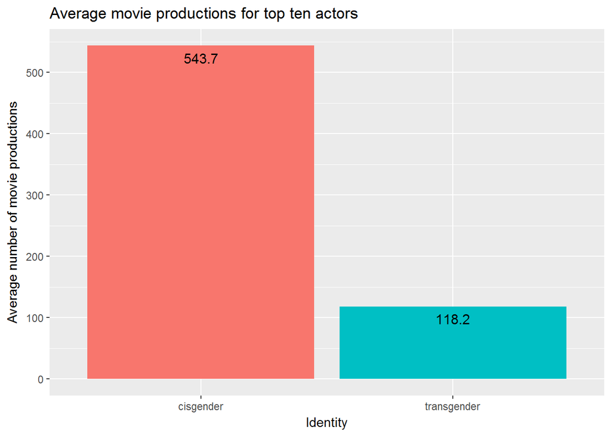

```r
# = 543.7

produc <- c(543.7, 118.2)
ids <- c("cisgender", "transgender")
df3 <- data.frame(produc, ids)

ggplot(df3, aes(x = ids, y = produc, fill = ids)) +
  geom_col(width = .9) +
  ylab("Average number of movie productions") +
  xlab("Identity") +
  guides(fill=FALSE) +
  scale_y_continuous(breaks = c(0, 100, 200, 300, 400, 500)) +
  geom_text(aes(label = produc), nudge_y = -20, size = 4) +
  ggtitle("Average movie productions for top ten actors")
```

### Relevant External Information:

For part of our project, we also wanted to look at how the database changed over time. However, public logs are not available. In searching for the history of the database, we also found that any user could submit edits to the database. After our analysis, we propose to submit changes to the *IMDB* database to make it more inclusive in terms of gender. The ‘gender’ column should include a wide range of gender identities, and remove previous and incorrect entries for gender.

### Future Work and Suggestions:

Further investigation could look into the gross values for each movie where main characters were trans, compared to the same values for non-trans main characters. We also recomend that the *IMDB* consider updating its information for trans folk, and consider updating the gender classification system from binary to a non-binary system.

#### Special Thanks:

This project was made possible by Smith College, IMDB, GitHub, MySQL Workbench, and Google Docs. We would like to add an extra special thanks to google docs for enabling quality organization and collaboration[^6]. The issue tab was some help in planing our initial launch of this project [^7].

```r
wordcountaddin::text_stats("Mini-Project-4.Rmd")
```

[^1]: [Link to Laverne Cox’s *IMDB* page](https://www.imdb.com/name/nm1209545/?ref_=nv_sr_1)
[^2]: [Link to Caitlyn Jenner’s *IMDB* page](https://www.imdb.com/name/nm0421063/?ref_=nv_sr_1)
[^3]: [Link to Joanna Fang’s *IMDB* Page](https://www.imdb.com/name/nm4825197/)
[^4]: [Link to trans-actors on *IMDB*](https://www.imdb.com/list/ls072599514/)
[^5]: [Link to cisgender acrots on *IMDB*](https://www.imdb.com/list/ls004429898/)
[^6]: [Link to the google doc](https://docs.google.com/document/d/1EBqizrotfOURJ1xrsDGW8TogOGQZzB0M3ZaC8GzVWLM/edit?usp=sharing)
[^7]: [Link to the GitHub repository](https://github.com/EmilyGrote/MiniProject4.git)